# wandering_morphemes

## Preliminaries

This chunk of code loads some packages and defines helper functions.

```r
knitr::opts_chunk$set(echo = TRUE)

# install CRAN packages (if not yet installed)
sapply(c("data.table", "tidyverse", "devtools", "party", "Hmisc", "rms", "RColorBrewer", "readxl"), function(x)
  if(!is.element(x, installed.packages())) install.packages(x, dependencies = T))

# install non-CRAN packages (if not yet installed)
if(!is.element("wizard", installed.packages())) {
  devtools::install_github("hartmast/wizard")
}

# load packages
library(tidyverse)
library(data.table)
library(wizard)
library(party)
library(Hmisc)
library(rms)
library(RColorBrewer)
library(readxl)

# quick barplot function
qbarplot2 <- function(df, ..., color = c("Blues", F), angle = 0) {

  if(missing(color)) { color = "Blues"  }

  p <- qbarplot(df, cex = 5, ...) + theme_bw() +
    theme(axis.text = element_text(size = 18)) +
    theme(axis.title = element_text(size = 18)) +
    theme(strip.text = element_text(size = 18)) +
    theme(legend.text = element_text(size = 18)) +
    theme(legend.title = element_text(size = 18, face = "bold")) +
    theme(text = element_text(size = 18))

  if(angle!=0) {
    p <- p + theme(axis.text.y = element_text(size = 18)) +
      theme(axis.text.x = element_text(angle = angle, size = 18,hjust = .9))
  } else {
    if(angle!=0) {
     p <- p + theme(axis.text = element_text(size = 18))
    }
  }


  if(color == "Blues") {
    p <- p + scale_fill_brewer("Blues")
  }

  return(p)

}
```

## Read data

This code reads and binds the data:

```r
# read data
ws <- read_csv("wegens/wegens_DECOW16BX_anno.csv")
ws <- mutate(ws, cxn = "wegens")
w0 <- read_csv("wegens/wegen_sample_DECOW16BX_anno.csv")
w0 <- mutate(w0, cxn = "wegen")
uws <- read_csv("willens/um_willens_DECOW16B.csv")
uws <- mutate(uws, cxn = "willens")
uw0 <- read_csv("willens/um_willen_DECOW16B_sample.csv")
uw0 <- mutate(uw0, cxn = "willen")

# add empty position column for willens (so that rbind works in the next step)
uws <- mutate(uws, position = NA)
uw0 <- mutate(uw0, position = NA)

# bind all together
w <- rbind(uws, uw0, ws, w0)
```

## Gender distribution

This code plots the distribution of grammatical genders in the data:

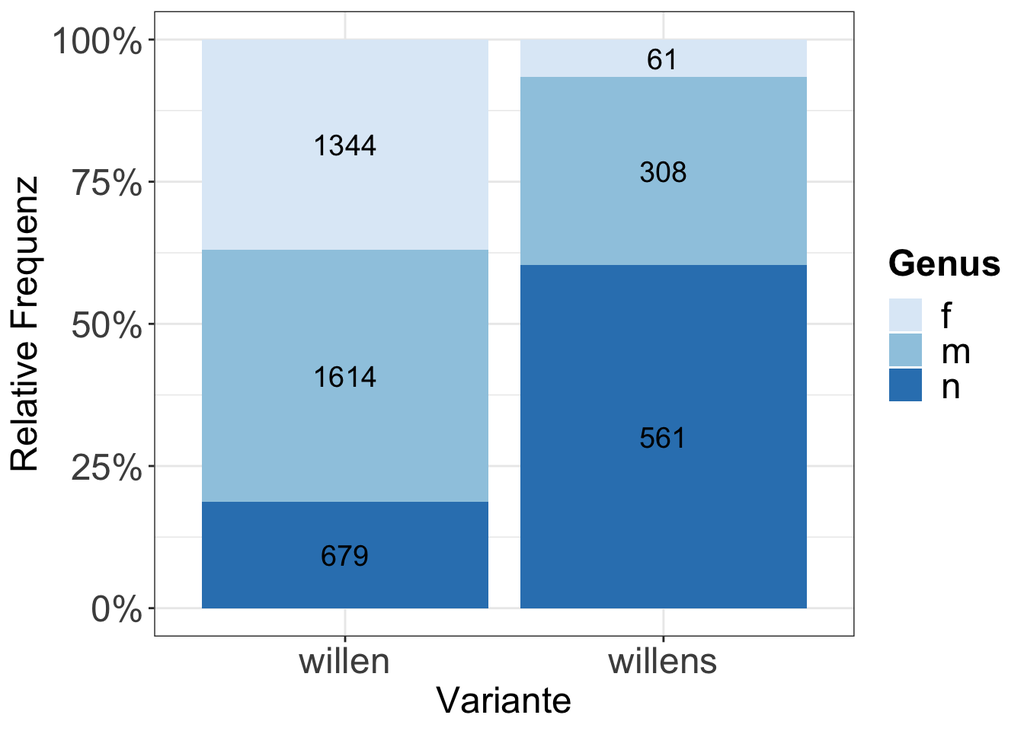

```r
# distinction between strong and weak masculines
w$klasse <- NA
w[which(w$Gender %in% c("m", "n") & w$s_less=="x" & w$Number=="sg"),]$klasse <- "schwach"
w[which(is.na(w$klasse)),]$klasse <- "nicht_schwach"

# willen(s)
w %>% filter(cxn %in% c("willens", "willen")) %>%
  filter(Gender %in% c("f", "m", "n")) %>%
  qbarplot2(cxn, Gender,
                                                            ylab = "Relative Frequenz", xlab = "Variante") + guides(fill = guide_legend(title = "Genus"))
```

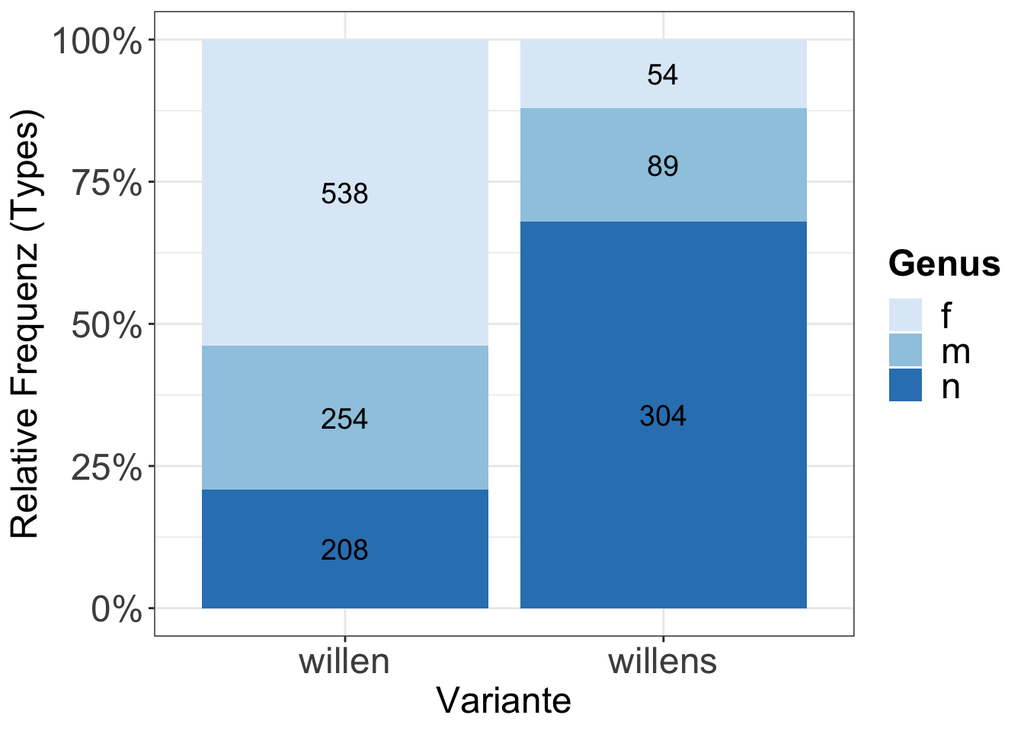

```r
# for types rather than tokens

willen_s <- filter(w, cxn %in% c("willens", "willen"))
willen_s[!duplicated(willen_s$lemma),] %>%
    filter(Gender %in% c("f", "m", "n")) %>%
  qbarplot2(cxn, Gender,
                                                            ylab = "Relative Frequenz (Types)", xlab = "Variante") + guides(fill = guide_legend(title = "Genus"))
```

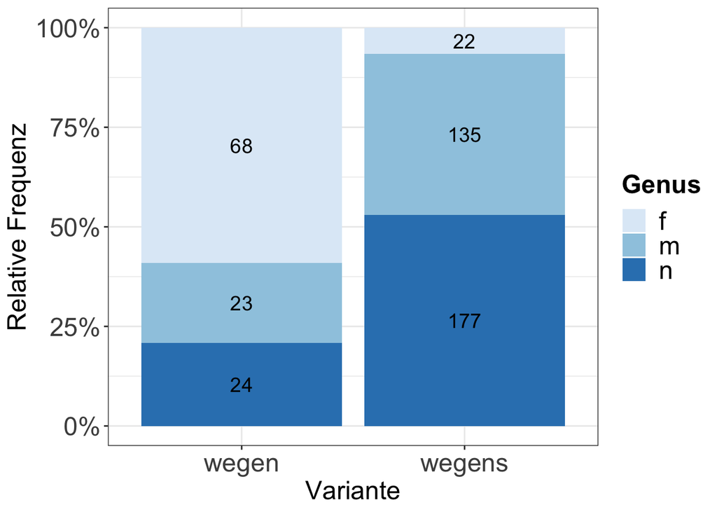

```r
# wegen(s)
w %>% filter(cxn %in% c("wegen", "wegens") & position=="post") %>%
  filter(Gender %in% c("f", "m", "n")) %>%
  qbarplot2(cxn, Gender,
                                                            ylab = "Relative Frequenz", xlab = "Variante") + guides(fill = guide_legend(title = "Genus"))
```

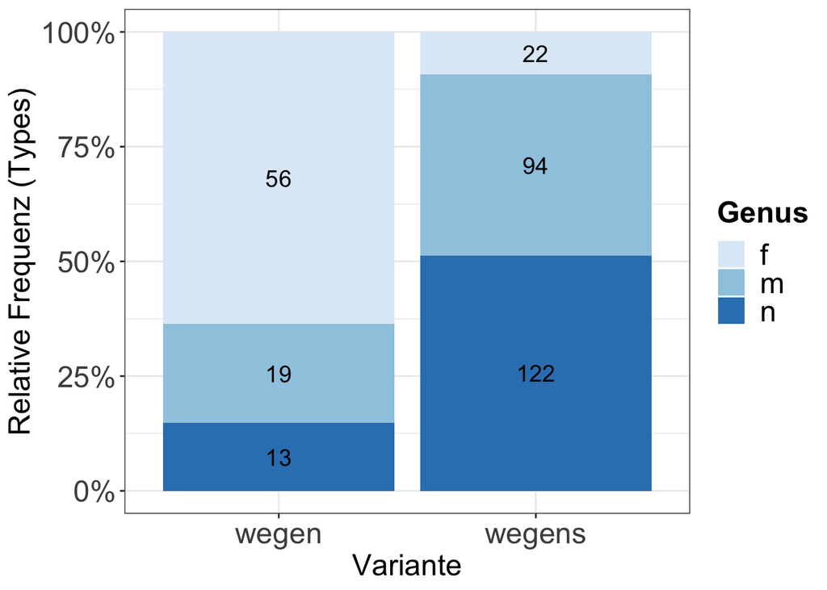

```r
# for types rather than tokens
wegen_s <- filter(w, cxn %in% c("wegen", "wegens") & position=="post")
wegen_s[!duplicated(wegen_s$lemma),] %>%
    filter(Gender %in% c("f", "m", "n")) %>%
  qbarplot2(cxn, Gender,
                                                            ylab = "Relative Frequenz (Types)", xlab = "Variante") + guides(fill = guide_legend(title = "Genus"))
```

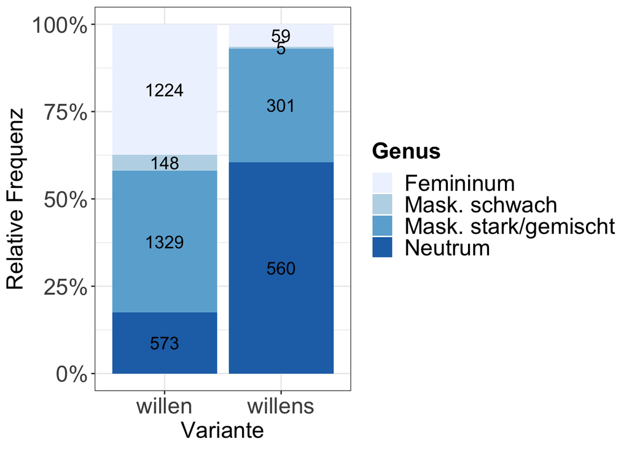

```r
# only singulars - distinction weak masculines vs. others ---

# add Genus column with distinction between weak and strong nouns
w$Genus <- ifelse(w$Gender=="m" & w$klasse=="schwach", "Mask. schwach", w$Gender)
w$Genus <- ifelse(w$Gender=="m" & w$klasse!="schwach", "Mask. stark/gemischt", w$Genus)
w$Genus <- ifelse(w$Genus=="f", "Femininum", w$Genus)
w$Genus <- ifelse(w$Genus=="n", "Neutrum", w$Genus)

# willen(s)
w %>% filter(cxn %in% c("willen", "willens") & Number=="sg" & Gender %in% c("m", "f", "n")) %>%
  qbarplot2(cxn, Genus, ylab = "Relative Frequenz", xlab = "Variante") +
  guides(fill = guide_legend(title = "Genus"))
```

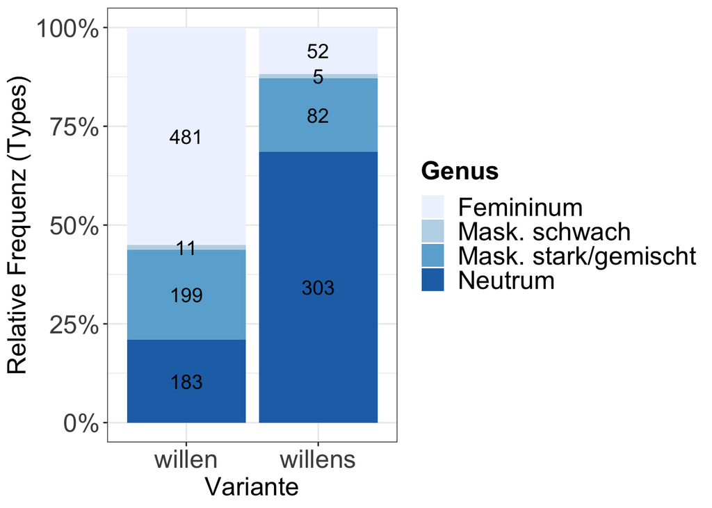

```r
# same for types rather than tokens
willen_s <- filter(w, cxn %in% c("willens", "willen"))
willen_s[!duplicated(willen_s$lemma),] %>% filter(Number=="sg" & Gender%in% c("m", "f", "n")) %>%
  qbarplot2(cxn, Genus, ylab = "Relative Frequenz (Types)", xlab = "Variante") +
  guides(fill = guide_legend(title = "Genus"))
```

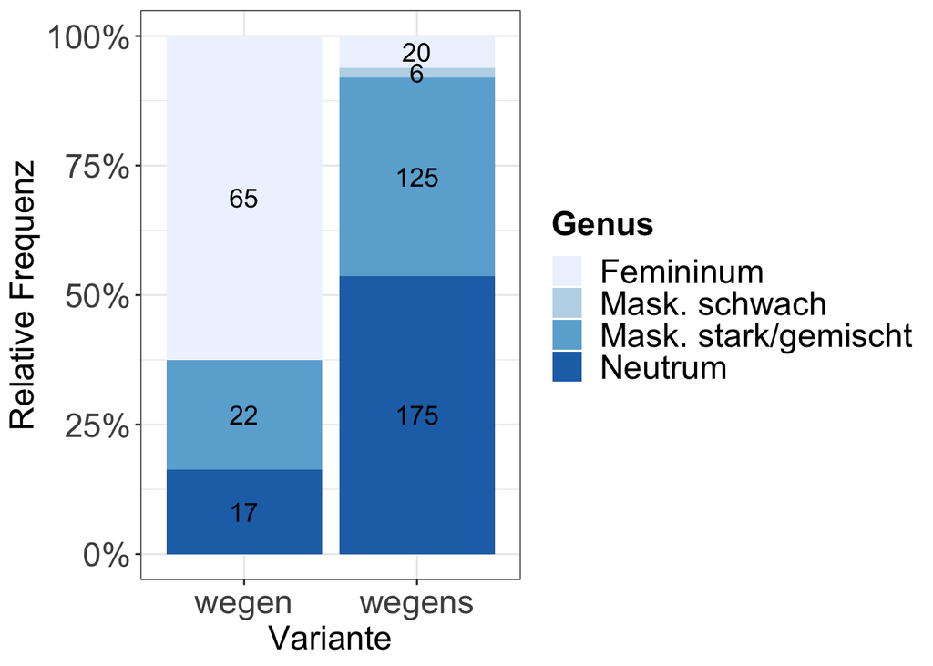

```r
# wegen(s)
w %>% filter(cxn %in% c("wegen", "wegens") & Number=="sg" & Gender %in% c("m", "f", "n") & position=="post") %>%
  qbarplot2(cxn, Genus, ylab = "Relative Frequenz", xlab = "Variante") +
  guides(fill = guide_legend(title = "Genus"))
```

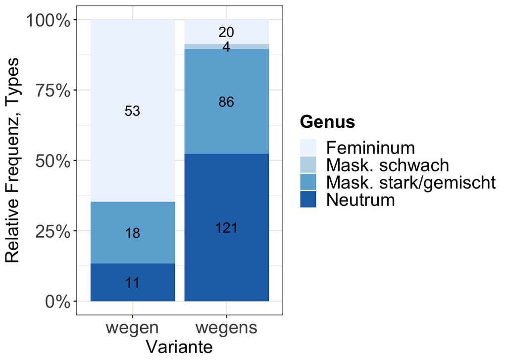

```r
# same for types rather than tokens
wegen_s <- filter(w, cxn %in% c("wegen", "wegens") & position=="post")
wegen_s[!duplicated(wegen_s$lemma),] %>% filter(Number=="sg" & Gender %in% c("m", "f", "n")) %>%   qbarplot2(cxn, Genus, ylab = "Relative Frequenz, Types", xlab = "Variante") +
  guides(fill = guide_legend(title = "Genus"))
```

## determiner distribution in wegens

```r
# binary coding for determiners
w$Det <- ifelse(w$Determiner=="none", "ohne Artikel", "mit Artikel")
```

## Number distribution

In plurals, there’s no genitive-s that could move. So if we are actually dealing with “wandering” case morphemes, we would expect plurals to be rarer in the wegens/willens datasets than in the canonical comparison data.

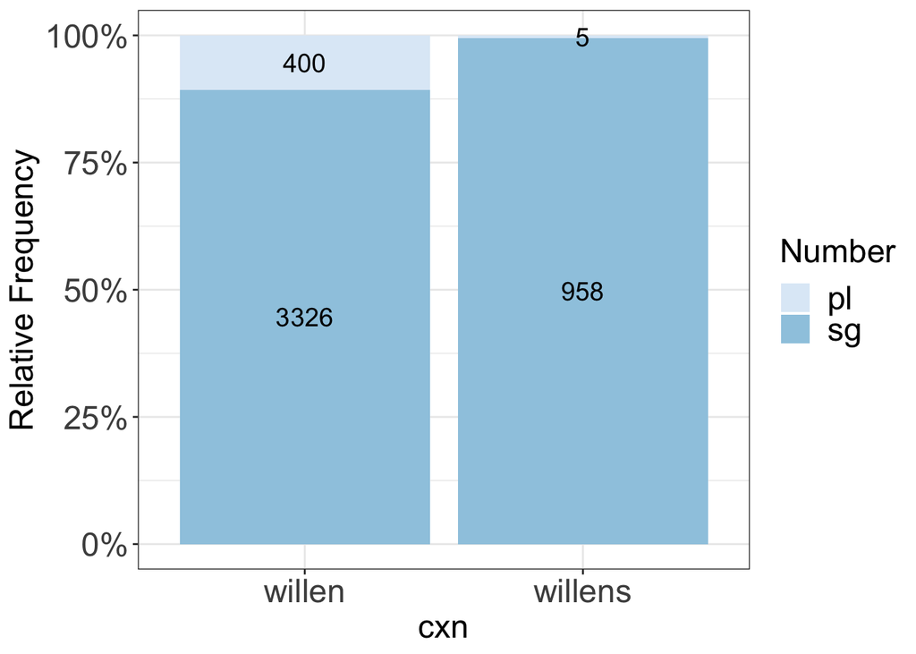

```r
w %>% filter(cxn %in% c("willens", "willen")) %>% qbarplot2(cxn, Number)
```

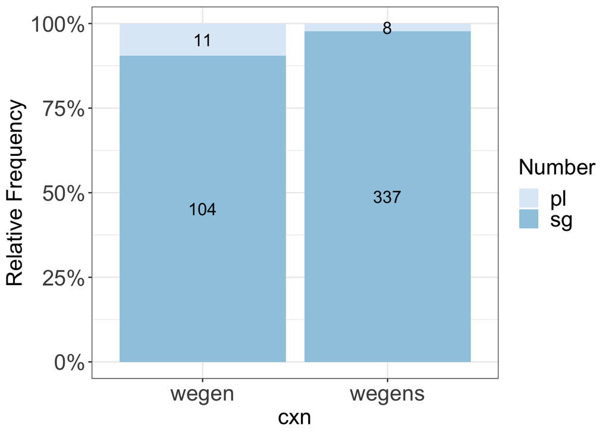

```r
w %>% filter(cxn %in% c("wegens", "wegen") & position=="post") %>% qbarplot2(cxn, Number)
```

## with or without s?

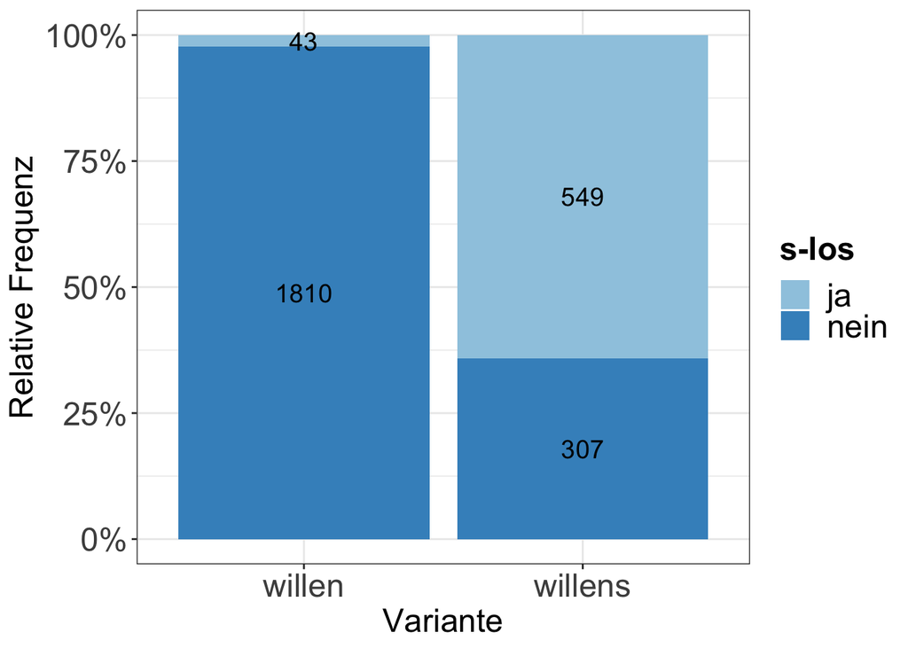

```r
w$s_los <- ifelse(w$s_less=="y", "ja", w$s_less)
w$s_los <- ifelse(w$s_less=="n", "nein", w$s_los)

w %>% filter(cxn %in% c("willen", "willens")) %>%
  filter(s_less %in% c("y", "n")) %>%
  qbarplot2(cxn, s_los, ylab="Relative Frequenz", xlab="Variante") +
  guides(fill = guide_legend(title = "s-los")) +
  scale_fill_manual(values = brewer.pal(9, "Blues")[c(4,6,8)])
```

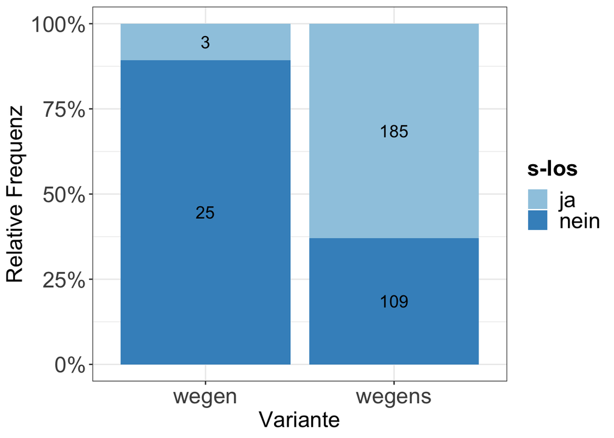

```r
w %>% filter(cxn %in% c("wegen", "wegens") & position=="post") %>%
  filter(s_less %in% c("y", "n")) %>%
  qbarplot2(cxn, s_los, ylab="Relative Frequenz", xlab="Variante") +
  guides(fill = guide_legend(title = "s-los")) +
  scale_fill_manual(values = brewer.pal(9, "Blues")[c(4,6,8)])
```

## Case distribution

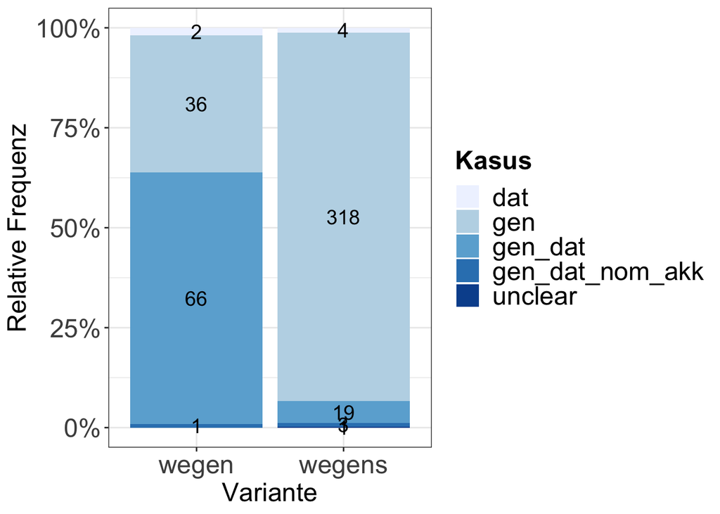

```r
w %>% filter(cxn %in% c("wegen", "wegens") & position == "post") %>% qbarplot2(cxn, case, ylab="Relative Frequenz", xlab="Variante") +
  guides(fill = guide_legend(title = "Kasus"))
```

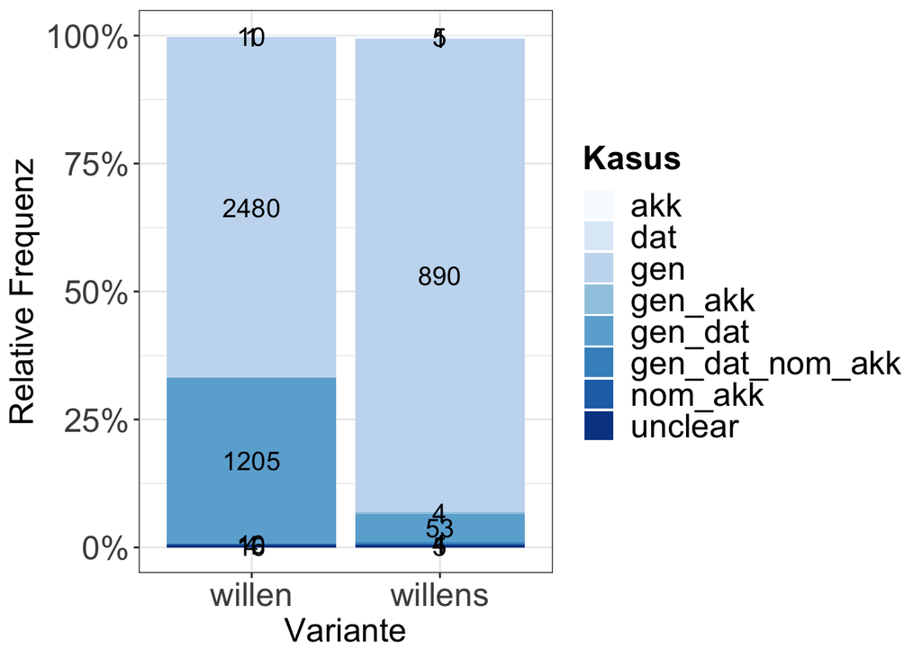

```r
# ggsave("wegen_case.png")

w %>% filter(cxn %in% c("willen", "willens")) %>% qbarplot2(cxn, case, ylab="Relative Frequenz", xlab="Variante") +
  guides(fill = guide_legend(title = "Kasus"))
```

```r
# ggsave("willen_case.png")
```

## Freq of adpositons

To get a glimpse of the distribution of adpositions in present-day language, as well as changes in the relative frequencies of adpositions over time, we plot the number of prepositions, posipositions and circumpositions in the “public” archive of [DWDS](https://www.dwds.de/), containing from the German Text Archive (DTA) and from corpora of contemporary German.

```r
appo <- read_xlsx("more/appositions.xlsx", 1)
appo2 <- read_xlsx("more/appositions.xlsx", 2)

appo <- left_join(appo, appo2)
```

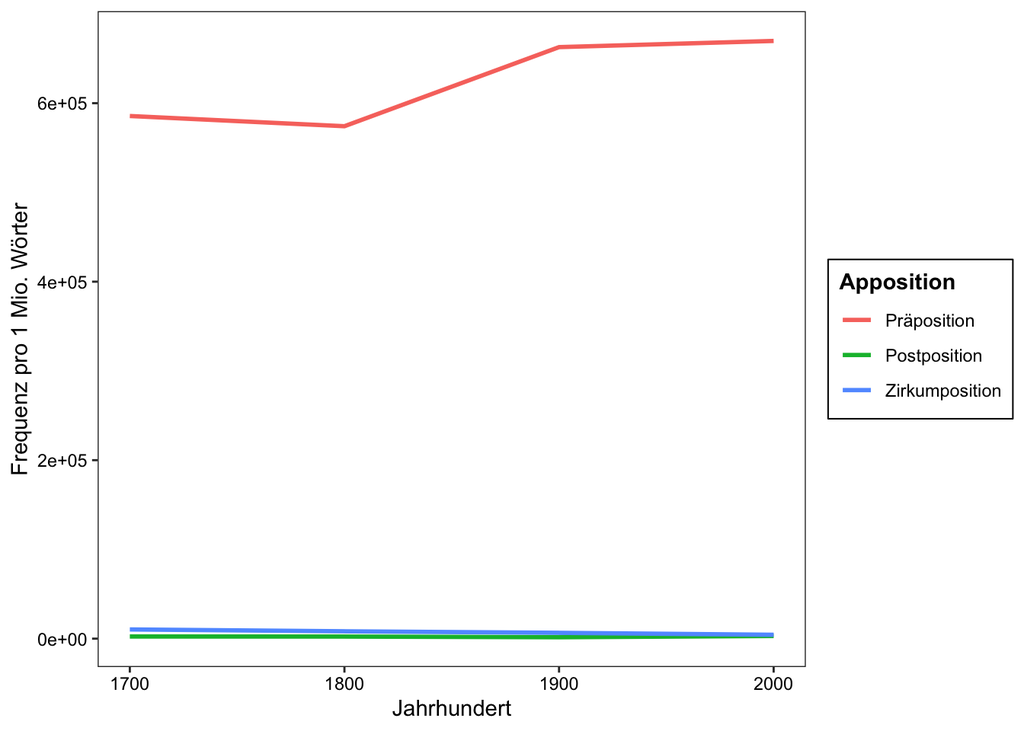

```r
appo$rel <- appo$Freq / appo$Freq_all

appo$Apposition <- case_when(appo$Appo == "APPR" ~ "Präposition",
          appo$Appo == "APZR" ~ "Zirkumposition",
          appo$Appo == "APPO" ~ "Postposition")
appo$Apposition <- factor(appo$Apposition, levels = c("Präposition", "Postposition", "Zirkumposition"))

appo %>% filter(Decade > 1600) %>% ggplot(aes(x = Decade, y = rel * 1e6, group = Apposition, col = Apposition)) +
  geom_line(lwd = 1) + theme_bw() + ylab("Frequenz pro 1 Mio. Wörter") + xlab("Jahrhundert") + guides(fill = guide_legend(title = "Apposition")) +
  theme(
     panel.background = element_rect(fill='transparent'), #transparent panel bg
    plot.background = element_rect(fill='transparent', color=NA), #transparent plot bg
     panel.grid.major = element_blank(), #remove major gridlines
     panel.grid.minor = element_blank(), #remove minor gridlines
     legend.background = element_rect(fill='transparent'), #transparent legend bg
     legend.box.background = element_rect(fill='transparent') #transparent legend panel
   ) + theme(axis.text = element_text(color =
                                       "black")) +
   theme(axis.title = element_text(color = "black")) +
   theme(strip.text = element_text(color = "black")) +
   theme(legend.text = element_text(color = "black")) +
   theme(legend.title = element_text(color = "black", face = "bold")) + theme(text = element_text(color = "black"))
```

```r
# ggsave("appositionen_dta.png")
```

## Random Forest

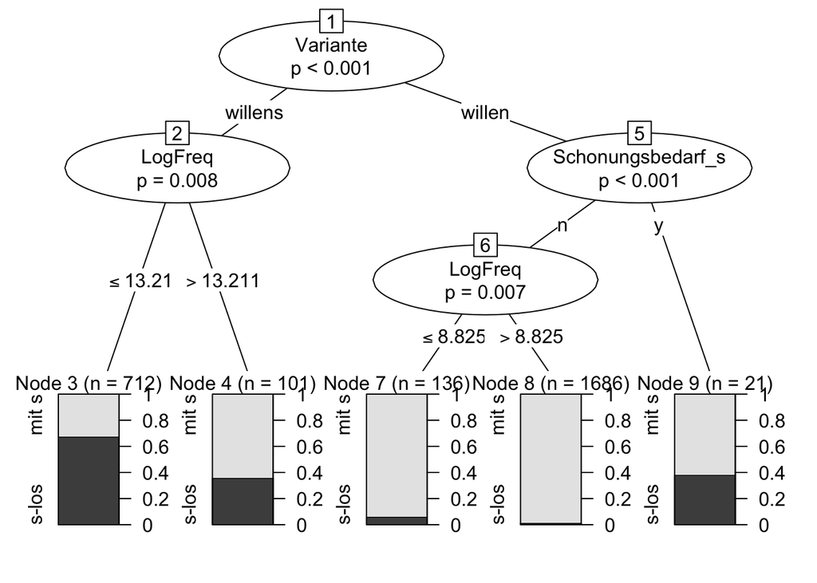

```r
# subset with strong masculines and neuters
s <- filter(w, s_less %in% c("y", "n") & case=="gen" & !is.na(Freq))

# convert categorical columns to factors
cols <- c("s_less", "cxn", "monoref", "forum", "abbreviation")
s[cols] <- lapply(s[cols], as.factor)

# add adposition column
s$app <- ifelse(s$NP_ext=="app", "y", "n")
s$app <- factor(s$app)

# add binary proper name column
s$name <- factor(ifelse(s$Proper_name!="n", "y", "n"))

# willen(s)
s2 <- select(s, s_less, cxn, monoref, name, app, Freq, pn_or_acro_or_nonnative_in_s, abbreviation, position, Determiner)

# use more intuitive names
colnames(s2) <- c("s_los", "Variante", "Monoreferenz", "Eigenname", "Apposition", "Frequenz", "Schonungsbedarf_s", "Kurzwort", "Position", "Determinierer")

# replace NAs
s2 <- replace_na(s2, list(Schonungsbedarf_s = "n"))
s2$Schonungsbedarf_s <- factor(s2$Schonungsbedarf_s)

# German s-los column
s2$s_los <- ifelse(s2$s_los=="n", "mit s", "s-los")
s2$s_los <- factor(s2$s_los, levels = rev(c("s-los", "mit s")))

# log frequency
s2$LogFreq <- log(s2$Frequenz)

# input for trees
s2a <- filter(s2, Variante %in% c("willens", "willen"))
s2b <- filter(s2, Variante %in% c("wegens", "wegen") & Position=="post")



# willen(s) -------------------------------------

# ctree
stree <- ctree(s_los ~ Variante + Monoreferenz + Apposition + Eigenname + Kurzwort + Schonungsbedarf_s + LogFreq, data = s2a)

# png("willens_tree.png", width = 10, height = 6, un = "in", res = 300)
plot(stree)
```

```r
# dev.off()


# random forest
sforest <- cforest(s_los ~ Variante + Monoreferenz + Apposition + Eigenname + Kurzwort + Schonungsbedarf_s + LogFreq, data = s2a)


# get index of concordance - code
# adapted from Tagliamonte & Baayen 2012
s2.trp = treeresponse(sforest)
s2a$PredFOREST <- sapply(s2.trp, FUN = function(v)return(v[2]))
s2a$s_los_bin <- (s2a$s_los=="s-los") + 0
somers2(s2a$PredFOREST, s2a$s_los_bin)
```

```
##            C          Dxy            n      Missing
##    0.9478788    0.8957577 2656.0000000    0.0000000
```

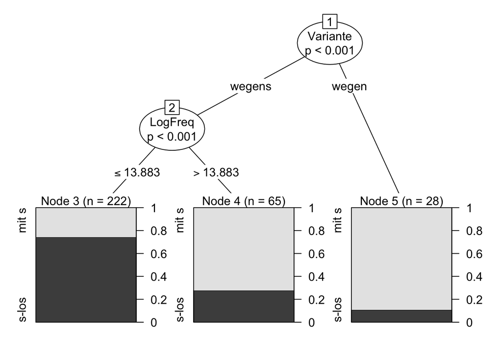

```r
# wegen(s) -------------------------------

# ctree
s2b$Determinierer <- factor(s2b$Determinierer)
stree <- ctree(s_los ~ Variante + Monoreferenz + Apposition +
                 Eigenname + Kurzwort + Schonungsbedarf_s + LogFreq, data = s2b)

# png("wegens_tree.png", width = 7.5, height = 5, un = "in", res = 300)
plot(stree)
```

```r
# dev.off()


# random forest
sforest <- cforest(s_los ~ Variante + Monoreferenz + Apposition + Eigenname + Kurzwort + Schonungsbedarf_s + LogFreq, data = s2b)


# get index of concordance - code
# adapted from Tagliamonte & Baayen 2012
s2.trp <- treeresponse(sforest)
s2b$PredFOREST <- sapply(s2.trp, FUN = function(v)return(v[2]))
s2b$s_los_bin <- (s2b$s_los=="s-los") + 0
somers2(s2b$PredFOREST, s2b$s_los_bin)
```

```
##           C         Dxy           n     Missing
##   0.8370634   0.6741269 315.0000000   0.0000000
```